# Project 1: Wrangling, Exploration, Visualization

SDS322E

## Data Wrangling, Exploration, Visualization

### Haley Harnitchek hmh2475

#### Introduction

*I chose my Spotify data and the classic rock song list from the fivethirtyeight data sets. I chose these because I wanted to see how often I listen to the songs in comparison to the amount of times they haave played on the radio. In addition, I grew up listening to class rock, and I still listen to it to this day. I wanted to see if I listen to it as often as I would like. I also wanted to see if there was a correlation between popular rock songs and which ones I listen to, so I can see if I was more likely to listen to them if they were popular.*

```r
library(tidyverse)
classic_rock <- fivethirtyeight::classic_rock_song_list
spotify_data <- read_csv("StreamingHistory0.csv")
```

#### Tidying: Reshaping

```r
spotify_data <- spotify_data %>% rename(Date = endTime, artist = artistName,
    song = trackName)
spotify_data <- spotify_data %>% group_by(song) %>% mutate(my_playcount = n())
```

*To join the data sets, I changed the endTime variable to “Date”, artistName to “artist”, and trackName to “song”. I also mutated my_playcount to see how often I lostened to specific songs.*

```r
glimpse(spotify_data)
```

```
## Rows: 7,196
## Columns: 5
## Groups: song [2,518]
## $ Date         <dttm> 2020-09-19 23:23:00, 2020-09-26 23:02:00, 2020-09-26 23…
## $ artist       <chr> "Taylor Swift", "Taylor Swift", "Taylor Swift", "Taylor …
## $ song         <chr> "exile (feat. Bon Iver)", "the last great american dynas…
## $ msPlayed     <dbl> 161351, 4527, 15882, 36524, 239560, 37709, 5665, 261920,…
## $ my_playcount <int> 3, 7, 3, 7, 5, 3, 3, 4, 7, 3, 4, 4, 6, 4, 4, 3, 4, 4, 3,…
```

```r
glimpse(classic_rock)
```

```
## Rows: 2,229
## Columns: 7
## $ song               <chr> "Caught Up in You", "Fantasy Girl", "Hold On Loose…
## $ artist             <chr> ".38 Special", ".38 Special", ".38 Special", ".38 …
## $ release_year       <int> 1982, NA, 1981, 1980, 1975, 2000, 2000, 2002, 1992…
## $ combined           <chr> "Caught Up in You by .38 Special", "Fantasy Girl b…
## $ has_year           <lgl> TRUE, FALSE, TRUE, TRUE, TRUE, TRUE, TRUE, TRUE, T…
## $ playcount          <int> 82, 3, 85, 18, 1, 13, 1, 6, 3, 1, 1, 97, 6, 5, 85,…
## $ playcount_has_year <int> 82, 0, 85, 18, 1, 13, 1, 6, 3, 1, 0, 97, 6, 0, 85,…
```

#### Joining/Merging

```r
song_match <- right_join(classic_rock, spotify_data, by = c("song",
    "artist"))
anti_join(classic_rock, spotify_data, by = c("song", "artist"))
```

```
## # A tibble: 2,114 x 7
##    song     artist  release_year combined    has_year playcount playcount_has_y…
##    <chr>    <chr>          <int> <chr>       <lgl>        <int>            <int>
##  1 Caught … .38 Sp…         1982 Caught Up … TRUE            82               82
##  2 Fantasy… .38 Sp…           NA Fantasy Gi… FALSE            3                0
##  3 Hold On… .38 Sp…         1981 Hold On Lo… TRUE            85               85
##  4 Rockin'… .38 Sp…         1980 Rockin' In… TRUE            18               18
##  5 Art For… 10cc            1975 Art For Ar… TRUE             1                1
##  6 Loser    3 Door…         2000 Loser by 3… TRUE             1                1
##  7 What's … 4 Non …         1992 What's Up?… TRUE             3                3
##  8 Take On… a-ha            1985 Take On Me… TRUE             1                1
##  9 Baby, P… AC/DC             NA Baby, Plea… FALSE            1                0
## 10 Back In… AC/DC           1980 Back In Bl… TRUE            97               97
## # … with 2,104 more rows
```

```r
semi_join(classic_rock, spotify_data, by = c("song", "artist"))
```

```
## # A tibble: 115 x 7
##    song     artist  release_year combined    has_year playcount playcount_has_y…
##    <chr>    <chr>          <int> <chr>       <lgl>        <int>            <int>
##  1 Krypton… 3 Door…         2000 Kryptonite… TRUE            13               13
##  2 When I'… 3 Door…         2002 When I'm G… TRUE             6                6
##  3 Dirty D… AC/DC           1976 Dirty Deed… TRUE            85               85
##  4 Moneyta… AC/DC             NA Moneytalks… FALSE           20                0
##  5 T.N.T.   AC/DC           1975 T.N.T. by … TRUE            66               66
##  6 Thunder… AC/DC           1990 Thunderstr… TRUE            34               34
##  7 You Sho… AC/DC           1980 You Shook … TRUE           138              138
##  8 Cryin'   Aerosm…         1993 Cryin' by … TRUE            15               15
##  9 Dream On Aerosm…         1973 Dream On b… TRUE           142              142
## 10 No More… Aerosm…         1975 No More No… TRUE             2                2
## # … with 105 more rows
```

```r
song_match <- song_match %>% arrange(artist) %>% distinct(song,
    .keep_all = T)
glimpse(song_match)
```

```
## Rows: 2,518
## Columns: 10
## $ song               <chr> "Bye Bye Bye", "Birthday Song", "Darth Vader", "He…
## $ artist             <chr> "*NSYNC", "2 Chainz", "21 Savage", "21 Savage", "2…
## $ release_year       <int> NA, NA, NA, NA, NA, NA, NA, NA, 2000, 2002, NA, NA…
## $ combined           <chr> NA, NA, NA, NA, NA, NA, NA, NA, "Kryptonite by 3 D…
## $ has_year           <lgl> NA, NA, NA, NA, NA, NA, NA, NA, TRUE, TRUE, NA, NA…
## $ playcount          <int> NA, NA, NA, NA, NA, NA, NA, NA, 13, 6, NA, NA, NA,…
## $ playcount_has_year <int> NA, NA, NA, NA, NA, NA, NA, NA, 13, 6, NA, NA, NA,…
## $ Date               <dttm> 2020-12-23 19:07:00, 2021-04-12 14:07:00, 2021-07…
## $ msPlayed           <dbl> 200333, 1429, 1880, 204826, 1880, 29823, 6389, 155…
## $ my_playcount       <int> 5, 2, 1, 1, 1, 1, 1, 7, 6, 8, 7, 1, 1, 3, 4, 2, 1,…
```

#### Wrangling

```r
song_match <- song_match %>% mutate(secPlayed = msPlayed/1000) %>%
    separate(Date, into = c("Date", "Time"), sep = 11, remove = F)
song_match <- song_match %>% separate(Date, into = c("Year",
    "Month", "Day"), sep = "-", remove = F) %>% separate(Time,
    into = c("Hour", "Min", "Sec"), sep = ":", remove = F)
song_match <- song_match %>% select(-Date, -msPlayed, -Sec, -Time)
song_match <- song_match %>% select(-has_year, -playcount_has_year)
glimpse(song_match)
```

```
## Rows: 2,518
## Columns: 12
## $ song         <chr> "Bye Bye Bye", "Birthday Song", "Darth Vader", "Heart So…
## $ artist       <chr> "*NSYNC", "2 Chainz", "21 Savage", "21 Savage", "21 Sava…
## $ release_year <int> NA, NA, NA, NA, NA, NA, NA, NA, 2000, 2002, NA, NA, NA, …
## $ combined     <chr> NA, NA, NA, NA, NA, NA, NA, NA, "Kryptonite by 3 Doors D…
## $ playcount    <int> NA, NA, NA, NA, NA, NA, NA, NA, 13, 6, NA, NA, NA, NA, N…
## $ Year         <chr> "2020", "2021", "2021", "2021", "2021", "2021", "2021", …
## $ Month        <chr> "12", "04", "07", "08", "09", "09", "09", "12", "10", "1…
## $ Day          <chr> "23 ", "12 ", "07 ", "12 ", "21 ", "22 ", "23 ", "02 ", …
## $ Hour         <chr> "19", "14", "16", "22", "17", "23", "13", "05", "23", "2…
## $ Min          <chr> "07", "07", "32", "54", "39", "33", "52", "11", "12", "4…
## $ my_playcount <int> 5, 2, 1, 1, 1, 1, 1, 7, 6, 8, 7, 1, 1, 3, 4, 2, 1, 1, 3,…
## $ secPlayed    <dbl> 200.333, 1.429, 1.880, 204.826, 1.880, 29.823, 6.389, 15…
```

```r
song_match %>% distinct(song) %>% filter(str_detect(song, "Day$"))
```

```
## # A tibble: 8 x 1
##   song
##   <chr>
## 1 Groundhog Day
## 2 King for a Day
## 3 The New Day
## 4 A New Day
## 5 Hero Of The Day
## 6 King For A Day
## 7 Anthem of Our Dying Day
## 8 Good Day
```

*Using str_detect, I was able to see what songs contain the word “day”. There are only eight songs that contain this word in the data set.*

```r
song_match %>% summarize_all(function(x) sum(is.na(x)))
```

```
## # A tibble: 1 x 12
##    song artist release_year combined playcount  Year Month   Day  Hour   Min
##   <int>  <int>        <int>    <int>     <int> <int> <int> <int> <int> <int>
## 1     0      1         2412     2405      2405     0     0     0     0     0
## # … with 2 more variables: my_playcount <int>, secPlayed <int>
```

*This data shows how many NAs are present in this data set for each variable. The variable with the most NAs was release_year with 2412 N/As.*

```r
song_match %>% group_by(song) %>% arrange(desc(playcount))
```

```
## # A tibble: 2,518 x 12
## # Groups:   song [2,518]
##    song  artist release_year combined playcount Year  Month Day   Hour  Min
##    <chr> <chr>         <int> <chr>        <int> <chr> <chr> <chr> <chr> <chr>
##  1 Drea… Aeros…         1973 Dream O…       142 2021  06    "07 " 20    12
##  2 Swee… Aeros…         1975 Sweet E…       141 2021  06    "26 " 23    27
##  3 You … AC/DC          1980 You Sho…       138 2021  06    "03 " 21    57
##  4 More… Boston         1976 More Th…       134 2021  06    "07 " 20    05
##  5 Craz… Heart          1976 Crazy O…       125 2020  11    "22 " 23    04
##  6 Rene… Styx           1978 Renegad…       116 2021  08    "24 " 19    19
##  7 Magi… Heart          1976 Magic M…       115 2020  11    "22 " 23    10
##  8 Tom … Rush           1981 Tom Saw…       114 2021  06    "07 " 19    00
##  9 Barr… Heart          1977 Barracu…       113 2020  11    "22 " 00    18
## 10 The … Thin …         1976 The Boy…       106 2021  06    "26 " 14    05
## # … with 2,508 more rows, and 2 more variables: my_playcount <int>,
## #   secPlayed <dbl>
```

```r
song_match %>% group_by(song) %>% arrange(desc(my_playcount))
```

```
## # A tibble: 2,518 x 12
## # Groups:   song [2,518]
##    song  artist release_year combined playcount Year  Month Day   Hour  Min
##    <chr> <chr>         <int> <chr>        <int> <chr> <chr> <chr> <chr> <chr>
##  1 Edge… Miley…           NA <NA>            NA 2020  11    "21 " 06    32
##  2 Plas… Miley…           NA <NA>            NA 2020  12    "09 " 06    39
##  3 Zomb… Miley…           NA <NA>            NA 2020  11    "01 " 19    11
##  4 Midn… Miley…           NA <NA>            NA 2020  11    "21 " 15    02
##  5 The … Greta…           NA <NA>            NA 2021  08    "04 " 17    24
##  6 When… Greta…           NA <NA>            NA 2021  08    "04 " 17    28
##  7 Pris… Miley…           NA <NA>            NA 2020  11    "23 " 19    45
##  8 Welc… Bo Bu…           NA <NA>            NA 2021  06    "10 " 05    27
##  9 Watc… Greta…           NA <NA>            NA 2021  08    "04 " 17    32
## 10 driv… Olivi…           NA <NA>            NA 2021  01    "13 " 00    17
## # … with 2,508 more rows, and 2 more variables: my_playcount <int>,
## #   secPlayed <dbl>
```

```r
song_match %>% group_by(song, playcount) %>% na.omit %>% arrange(desc(my_playcount))
```

```
## # A tibble: 106 x 12
## # Groups:   song, playcount [106]
##    song  artist release_year combined playcount Year  Month Day   Hour  Min
##    <chr> <chr>         <int> <chr>        <int> <chr> <chr> <chr> <chr> <chr>
##  1 Holi… Green…         2004 Holiday…         5 2020  10    "21 " 21    09
##  2 Cali… Red H…         1999 Califor…         4 2020  10    "24 " 23    36
##  3 Loser Beck           1994 Loser b…         1 2020  10    "24 " 23    23
##  4 Iris  The G…         1998 Iris by…         2 2020  10    "30 " 21    38
##  5 Bask… Green…         1994 Basket …         5 2020  10    "07 " 01    06
##  6 The … The O…         1998 The Kid…         1 2020  10    "24 " 23    20
##  7 When… 3 Doo…         2002 When I'…         6 2020  10    "24 " 23    45
##  8 When… Green…         1994 When I …        14 2020  10    "30 " 20    06
##  9 My O… Lit            1999 My Own …         2 2020  10    "27 " 23    15
## 10 Scar… Red H…         1999 Scar Ti…         8 2020  10    "29 " 01    51
## # … with 96 more rows, and 2 more variables: my_playcount <int>,
## #   secPlayed <dbl>
```

```r
song_match %>% group_by(artist) %>% summarize(n = n()) %>% arrange(desc(n))
```

```
## # A tibble: 666 x 2
##    artist                 n
##    <chr>              <int>
##  1 Green Day             88
##  2 blink-182             64
##  3 Ludwig Goransson      63
##  4 Falling In Reverse    59
##  5 Alice In Chains       51
##  6 Taylor Swift          48
##  7 Rancid                45
##  8 Logic                 44
##  9 Metallica             43
## 10 Bo Burnham            42
## # … with 656 more rows
```

```r
song_match %>% group_by(Year, Month, Day) %>% summarize(n = n()) %>%
    arrange(desc(n))
```

```
## # A tibble: 187 x 4
## # Groups:   Year, Month [13]
##    Year  Month Day       n
##    <chr> <chr> <chr> <int>
##  1 2021  09    "21 "    99
##  2 2021  05    "27 "    90
##  3 2021  05    "26 "    76
##  4 2021  09    "23 "    68
##  5 2021  06    "03 "    60
##  6 2021  09    "01 "    54
##  7 2021  09    "22 "    53
##  8 2020  11    "08 "    44
##  9 2021  08    "31 "    44
## 10 2020  12    "21 "    41
## # … with 177 more rows
```

*The most listened song on the radio that was shared between the data sets was Dream On by Aerosmith with a playcount of 142 while mine was only a playcount of 3. My most listened song was “Edge of Midnight (Midnight Sky Remix)(feat. Stevie Nicks)” by Miley Cyrus with a person playcount of 37, which was not shared between the data sets. My most listened to song that was shared between the data sets was "Holiday / Boulevard of Broken Dreams by Green Day. I had a playcount of 13 while the radio had a playcount of 5. The artist that appears the most in this dataset is Green Day. I listened the most songs on September 21, 2021 since it appears the most in this data set.*

```r
song_match %>% summarize_if(is.numeric, list(min = min), na.rm = T)
```

```
## # A tibble: 1 x 4
##   release_year_min playcount_min my_playcount_min secPlayed_min
##              <int>         <int>            <int>         <dbl>
## 1             1964             1                1             0
```

```r
song_match %>% summarize_if(is.numeric, list(max = max), na.rm = T)
```

```
## # A tibble: 1 x 4
##   release_year_max playcount_max my_playcount_max secPlayed_max
##              <int>         <int>            <int>         <dbl>
## 1             2011           142               37         4368.
```

*These are the minimum and maximum values for all of the numeric variables in the data set. The ones with "_min" represent the minimum amount. The variables with the "_max" represent the maximum values.*

```r
song_match %>% summarize_if(is.numeric, list(Q3 = quantile),
    probs = 0.75, na.rm = T)
```

```
## # A tibble: 1 x 4
##   release_year_Q3 playcount_Q3 my_playcount_Q3 secPlayed_Q3
##             <dbl>        <dbl>           <dbl>        <dbl>
## 1            1994           60               3         219.
```

```r
song_match %>% summarize_if(is.numeric, list(Q1 = quantile),
    probs = 0.25, na.rm = T)
```

```
## # A tibble: 1 x 4
##   release_year_Q1 playcount_Q1 my_playcount_Q1 secPlayed_Q1
##             <dbl>        <dbl>           <dbl>        <dbl>
## 1            1976            4               1         14.1
```

*This data represents the first and third quantile of the data. The ones with "_Q1" represent the first quantile. The variables with the “Q3” represent the third quantile.*

```r
song_match %>% summarize_if(is.numeric, n_distinct)
```

```
## # A tibble: 1 x 4
##   release_year playcount my_playcount secPlayed
##          <int>     <int>        <int>     <int>
## 1           39        63           32      2261
```

*This data represents the distinct amounts of each numeric variable. The tells how many unique values of the numeric variables there are.*

```r
song_match %>% summarize_if(is.numeric, list(mean = mean), na.rm = T)
```

```
## # A tibble: 1 x 4
##   release_year_mean playcount_mean my_playcount_mean secPlayed_mean
##               <dbl>          <dbl>             <dbl>          <dbl>
## 1             1985.           37.4              2.86           143.
```

*This data represents the mean of each numeric variable.The ones with "_mean" represent the mean.*

```r
song_match %>% summarize_if(is.numeric, list(sd = sd), na.rm = T)
```

```
## # A tibble: 1 x 4
##   release_year_sd playcount_sd my_playcount_sd secPlayed_sd
##             <dbl>        <dbl>           <dbl>        <dbl>
## 1            10.8         39.2            4.08         171.
```

*This data represents the standard deviation of each numeric variable.The ones with "_sd" represent standard deviation.*

```r
song_match %>% group_by(song) %>% summarize(count = n()) %>%
    count
```

```
## # A tibble: 1 x 1
##       n
##   <int>
## 1  2518
```

```r
song_match %>% group_by(artist) %>% summarize(count = n()) %>%
    count
```

```
## # A tibble: 1 x 1
##       n
##   <int>
## 1   666
```

```r
song_match %>% group_by(combined) %>% summarize(count = n()) %>%
    count
```

```
## # A tibble: 1 x 1
##       n
##   <int>
## 1   114
```

*In this data set, there are 666 unique artists for all 2518 individual songs. There are 114 values for the combined variable.*

```r
cor_song <- song_match %>% select_if(is.numeric) %>% cor(use = "pair")
tidycor <- cor_song %>% as.data.frame %>% rownames_to_column("var1") %>%
    pivot_longer(-1, names_to = "var2", values_to = "correlation")
library(gt)

tidycor %>% gt %>% tab_header(title = md("**Correlation Between Numeric Variables**"),
    subtitle = md("A table of my `song_match` correlation"))
```

**Correlation Between Numeric Variables**

A table of my `song_match` correlation

| var1 | var2 | correlation |
| --- | --- | --- |
| release_year | release_year | 1.00000000 |
| release_year | playcount | -0.56140482 |
| release_year | my_playcount | 0.44322566 |
| release_year | secPlayed | 0.05811687 |
| playcount | release_year | -0.56140482 |
| playcount | playcount | 1.00000000 |
| playcount | my_playcount | -0.30166401 |
| playcount | secPlayed | -0.01949270 |
| my_playcount | release_year | 0.44322566 |
| my_playcount | playcount | -0.30166401 |
| my_playcount | my_playcount | 1.00000000 |
| my_playcount | secPlayed | 0.02951460 |
| secPlayed | release_year | 0.05811687 |
| secPlayed | playcount | -0.01949270 |
| secPlayed | my_playcount | 0.02951460 |
| secPlayed | secPlayed | 1.00000000 |

*This data represents the correlation between each numeric variable. It seems that there is a positive correlation between the amount of times I play a song and the year a song was released. There also seems to be a negative correlation between the amount of times the radio plays with the year a song was released.*

#### Visualizing

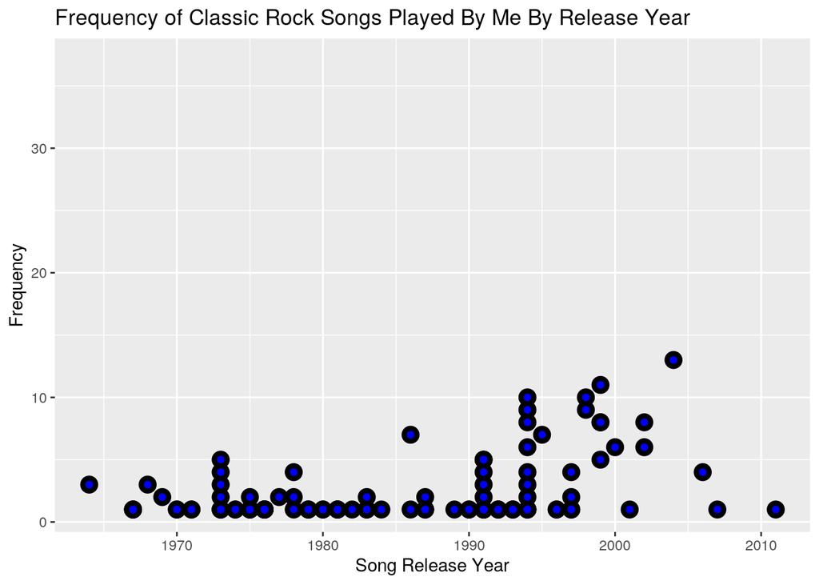

```r
ggplot(data = song_match, aes(x = release_year, y = my_playcount)) +
    geom_point(aes(size = 1)) + geom_point(color = "blue") +
    ggtitle("Frequency of Classic Rock Songs Played By Me By Release Year") +
    scale_y_continuous(name = "Frequency") + scale_x_continuous(name = "Song Release Year") +
    theme(legend.position = "none")
```

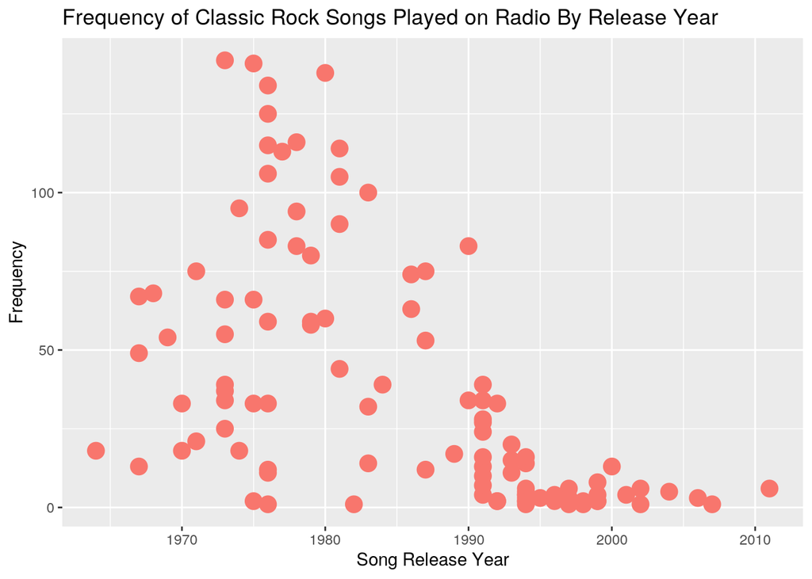

```r
ggplot(data = song_match, aes(x = release_year, y = playcount)) +
    geom_point(aes(col = "red", size = 1)) + ggtitle("Frequency of Classic Rock Songs Played on Radio By Release Year") +
    scale_y_continuous(name = "Frequency") + scale_x_continuous(name = "Song Release Year") +
    theme(legend.position = "none")
```

*These two plots are comparing the amount plays of each song between the radio and myself depending on how recently the songs were released. I was more likely to listen to classic rock songs released between 1990-2005 while the radio was more likely to play classic rock songs from 1970-1990. This shows that I tend to appreciate that era of music more.*

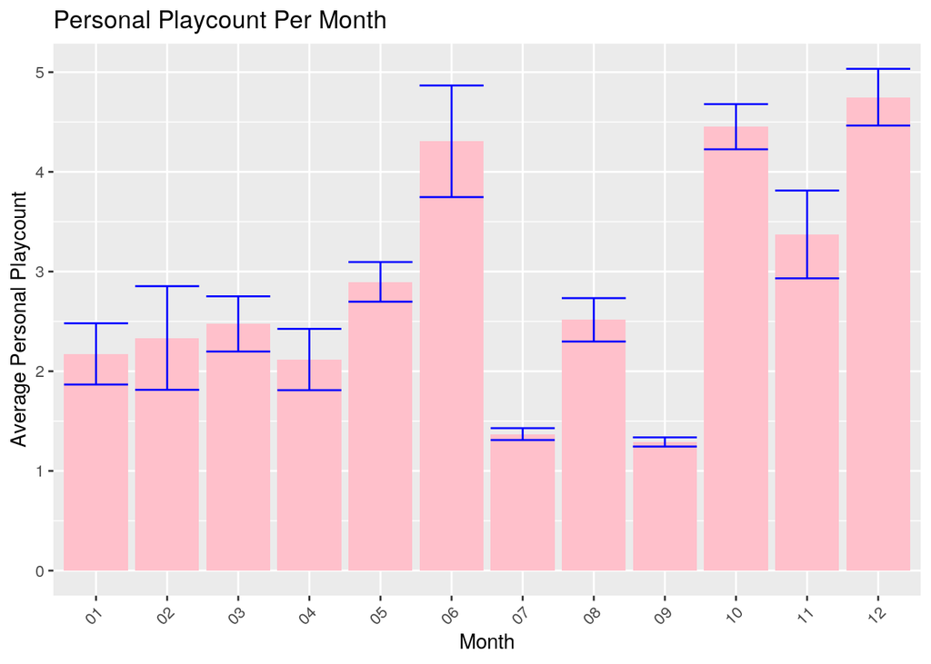

```r
ggplot(song_match, aes(x = Month, y = my_playcount)) + geom_bar(stat = "summary",
    fun = mean, fill = "pink") + geom_errorbar(stat = "summary",
    fun.data = mean_se, color = "blue") + theme(axis.text.x = element_text(angle = 45,
    hjust = 1), legend.position = "none") + scale_y_continuous(name = "Average Personal Playcount") +
    ggtitle("Personal Playcount Per Month")
```

*This graph shows the average amount of times I repeated a song last year. I apparently liked to re-listen to songs the most during December of 2020 with an average of about 4.7 plays. This could be due to the fact that Christmas is in December, which can lead to the constant repeat of songs.*

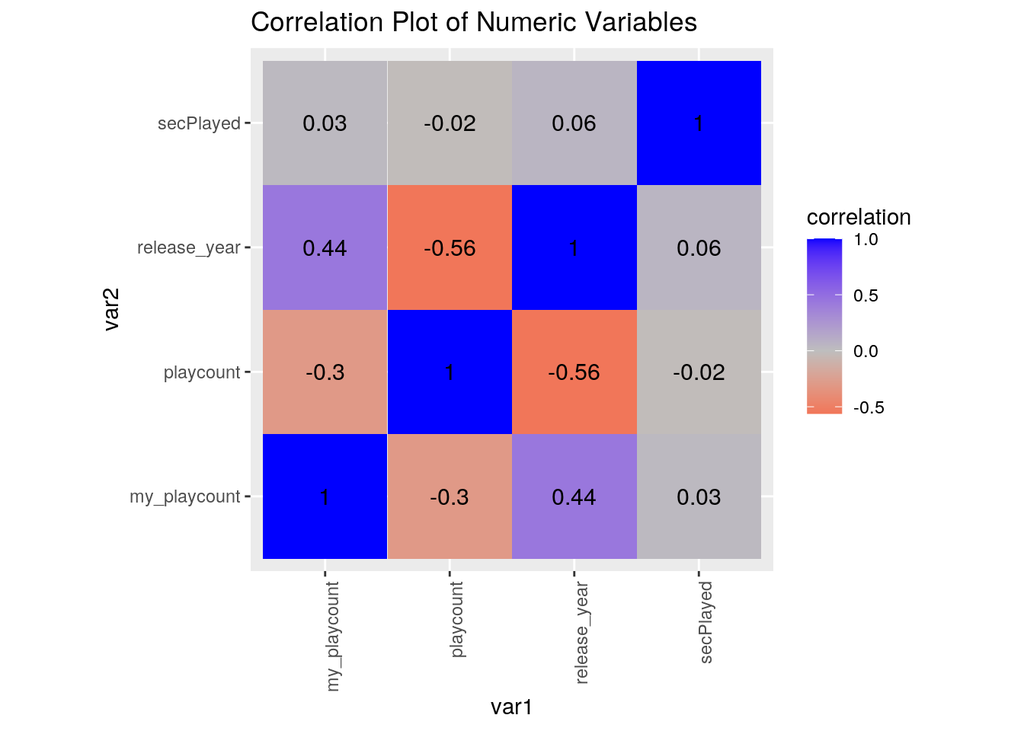

```r
tidycor %>% ggplot(aes(var1, var2, fill = correlation)) + geom_tile() +
    scale_fill_gradient2(low = "red", mid = "gray", high = "blue") +
    ggtitle("Correlation Plot of Numeric Variables") + geom_text(aes(label = round(correlation,
    2)), color = "black", size = 4) + theme(axis.text.x = element_text(angle = 90,
    hjust = 1)) + coord_fixed()
```

*This plot visualizes the correlation between all of the numeric statistics present in the data set. There were no significant findings in the correlation between the variables, but I did find it interesting that there is a positive correlation between release year and my playcount and a negative correlation between release year and the radio playcount. This chart visualizes the findings from the summary statistics data. Even though plot 1 shows that I tend to appreciate newer music more, this shows that that is not a significant finding as the correlation is not too strong r=0.44).*

#### Concluding Remarks

```r
# github stuff to put in terminal cd ~/project1 #cd to your
# project1 directory git add . git commit -m 'proj1 update'
# git remote add origin
# https://github.com/haleym2220/project1.git git push origin
# main
```

```r
# github stuff to put in terminal portfolio.Rmd
#- i class='fa fa-chart-line'> < </i> [Project 1: Description] (https://haleym2220/github.io/project1)
```